# R Final Report: Coral Spawning

Daniel, Annie, & River

2024-11-29

### Setting Up

```r
library(dplyr)
library(leaflet)
library(ggplot2)
library(lubridate)
library(forcats)
library(tidyr)
library(emmeans)
library(RColorBrewer)
```

```r
raw.data <- read.csv("data/CSD_Tables.csv")
```

##### This report is generated based on the Indo-Pacific coral spawning dataset organized by Baird et al. (2021). Our basic understanding of the dataset and the formation of the research question is inspired by Lin et al. (2021).

### Introduction

- Synchronized mass coral spawning is observed once a year worldwide and occurs days following a full moon.
- The lunar cycle (tide and moonlight) regulates environmental changes that can be detected by corals to coordinate mass spawning.
- This dataset includes coral spawning observations in different eco-regions (Figure 1).

[interactive chart not shown]

**Figure 1**: World map with all the observed coral spawning sites in 2016.

- The timing of synchronized mass coral spawning depends on whether coral gametes have matured yet.
- Gametes maturity varies between coral species and potentially influenced by environmental factors like temperature.
- We wonder whether there the coral spawning time is correlated with the latitude, where sites closer to the equator observe spawning earlier in the year.
- Zooming in the scope, we would also like to compare the spawning time of different coral genus between Taiwan and Japan (Figure 2).

[interactive chart not shown]

**Figure 2**: Map of coral spawning sites observed in Taiwan and Japan.

### Methods

#### Spawning time and geolocation

We downloaded the Indo-Pacific coral spawning database (Baird et al. 2021) from nature.com/sdata/. Using the `max` and `summary` functions, it is determined that the year 2016 has the most data entry. Using the `ggplot2` package, we plot the spawning data (date and location) from 2016.

```r
split <- raw.data %>%
  separate(Date, into = c("day", "month", "year"), sep = "/")
summary(as.factor(split$year))
```

```
## 1978 1979 1980 1981 1982 1983 1984 1985 1986 1987 1988 1989 1990 1991 1992 1993
##    9   17    6   69   96  241  147   18   23  141   25  229  165  166  134  214
## 1994 1995 1996 1997 1998 1999 2000 2001 2002 2003 2004 2005 2006 2007 2008 2009
##  116   88   37  113   31   79   51   33  130  110   75  102  164  142   93  111
## 2010 2011 2012 2013 2014 2015 2016 2017 2018 2019
##  115  170  346  165  379  365  589  328  369  177
```

```r
max(summary(as.factor(split$year))) # deternine most data year
```

```
## [1] 589
```

##### Spawning data from Taiwan and Japan

Using the `filter` function, we selected the genus that have spawning data in both Taiwan and Japan. We then made a boxplot to compare their *date of spawning relative to nearest full moon (DoSRtNFM).

```r
# select the countries needed (Taiwan & Japan)
spawning.jptw <- raw.data %>%
  filter(Country %in% c('Japan', 'Taiwan')) %>%
  filter(Genus %in% c('Galaxea', 'Lobophyllia', 'Coelastrea', 'Dipsastraea', 'Favites', 'Goniastrea', 'Platygyra', 'Porites'))

# delete the unneeded columns
spawning.jptw[ , c('Subsite', 'O_n', 'Depth_m', 'N', 'No_start', 'Quality_start', 'No_end', 'Quality_end', 'Gamete_release', 'Situation', 'Timezone', 'Reference', 'Comments')] <- list(NULL)
spawning.jptw$color <- ifelse(spawning.jptw$Country == "Japan", "#F8766D", "#00BFC4")
```

### Results

#### Spawning time and geolocation

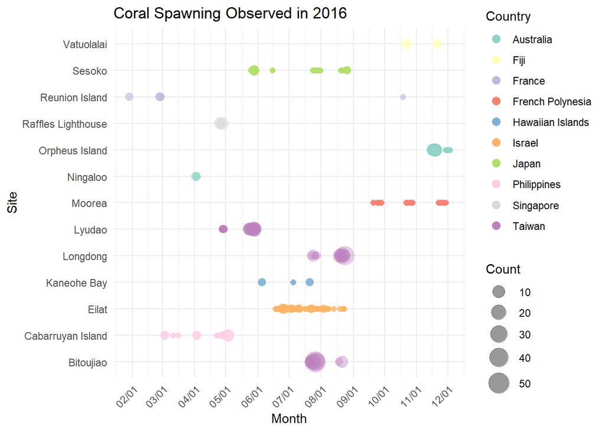

Notes  
World spawning figure:  
- I think the latitude order is messed up? Bitoujiao shouldn’t be at the bottom?  
- Change title to “Coral spawning observed in 2016”

##### Spawning data from Taiwan and Japan

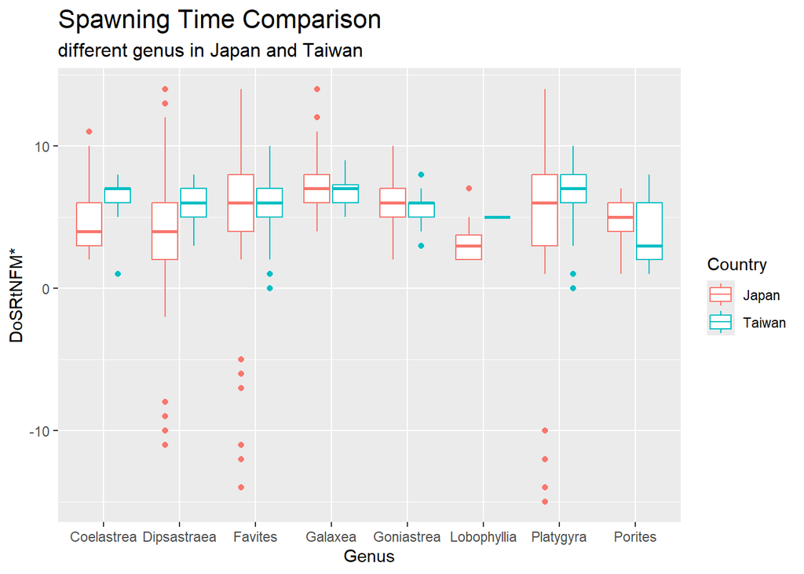

##### Stats

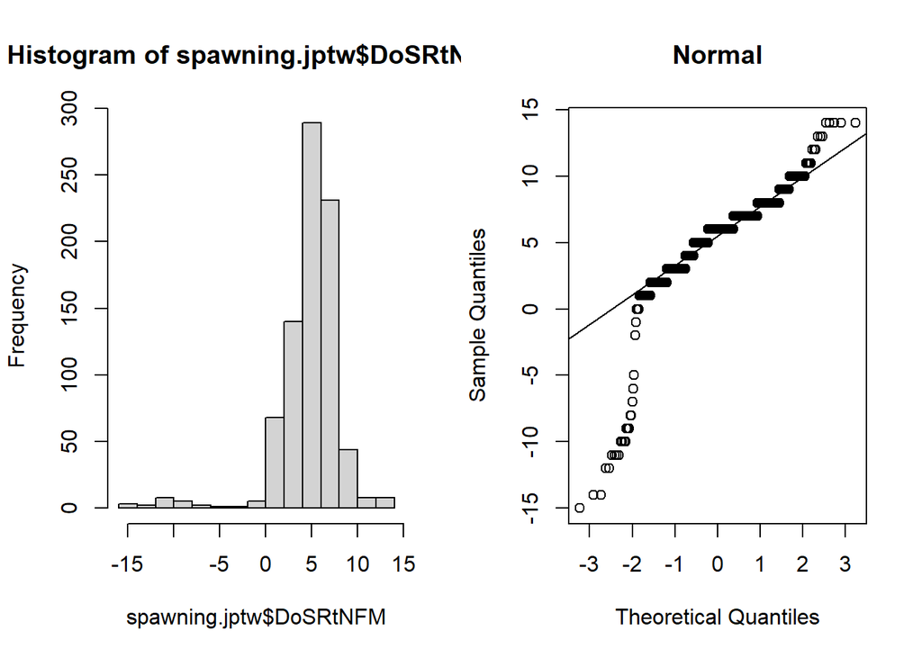

```r
#check normality----
par(mfrow = c(1, 2))
hist(spawning.jptw$DoSRtNFM)
qqnorm(spawning.jptw$DoSRtNFM, main = 'Normal')
qqline(spawning.jptw$DoSRtNFM)
```

```r
#check data number----
J.genus <- spawning.jptw %>%
          filter(Country == "Japan") %>%
          dplyr::select(Genus)
summary(as.factor(J.genus$Genus))
```

```
##  Coelastrea Dipsastraea     Favites     Galaxea  Goniastrea Lobophyllia
##          26          60         109          27          17          14
##   Platygyra     Porites
##          77          21
```

```r
T.genus <- spawning.jptw %>%
  filter(Country == "Taiwan") %>%
  dplyr::select(Genus)
summary(as.factor(T.genus$Genus))
```

```
##  Coelastrea Dipsastraea     Favites     Galaxea  Goniastrea Lobophyllia
##          20          34         249          12          24           1
##   Platygyra     Porites
##          59          65
```

sample size of *Lobophyllia* is too small, so there’s no comparison below

```r
#wilcoxon----
Coelastrea <- spawning.jptw %>%
  filter(Genus %in% "Coelastrea",
         Country %in% c("Taiwan", "Japan"))
wilcox.test(DoSRtNFM ~ Country, data = Coelastrea)
```

```
##
##  Wilcoxon rank sum test with continuity correction
##
## data:  DoSRtNFM by Country
## W = 147, p-value = 0.01138
## alternative hypothesis: true location shift is not equal to 0
```

```r
Dipsastraea <- spawning.jptw %>%
  filter(Genus %in% "Dipsastraea",
         Country %in% c("Taiwan", "Japan"))
wilcox.test(DoSRtNFM ~ Country, data = Dipsastraea)
```

```
##
##  Wilcoxon rank sum test with continuity correction
##
## data:  DoSRtNFM by Country
## W = 548.5, p-value = 0.0001827
## alternative hypothesis: true location shift is not equal to 0
```

```r
Favites <- spawning.jptw %>%
  filter(Genus %in% "Favites",
         Country %in% c("Taiwan", "Japan"))
wilcox.test(DoSRtNFM ~ Country, data = Favites)
```

```
##
##  Wilcoxon rank sum test with continuity correction
##
## data:  DoSRtNFM by Country
## W = 14270, p-value = 0.4295
## alternative hypothesis: true location shift is not equal to 0
```

```r
Galaxea <- spawning.jptw %>%
  filter(Genus %in% "Galaxea",
         Country %in% c("Taiwan", "Japan"))
wilcox.test(DoSRtNFM ~ Country, data = Galaxea)
```

```
##
##  Wilcoxon rank sum test with continuity correction
##
## data:  DoSRtNFM by Country
## W = 184.5, p-value = 0.4918
## alternative hypothesis: true location shift is not equal to 0
```

```r
Goniastrea <- spawning.jptw %>%
  filter(Genus %in% "Goniastrea",
         Country %in% c("Taiwan", "Japan"))
wilcox.test(DoSRtNFM ~ Country, data = Goniastrea)
```

```
##
##  Wilcoxon rank sum test with continuity correction
##
## data:  DoSRtNFM by Country
## W = 259.5, p-value = 0.1361
## alternative hypothesis: true location shift is not equal to 0
```

```r
Platygyra <- spawning.jptw %>%
  filter(Genus %in% "Platygyra",
         Country %in% c("Taiwan", "Japan"))
wilcox.test(DoSRtNFM ~ Country, data = Platygyra)
```

```
##
##  Wilcoxon rank sum test with continuity correction
##
## data:  DoSRtNFM by Country
## W = 1934, p-value = 0.1354
## alternative hypothesis: true location shift is not equal to 0
```

```r
Porites <- spawning.jptw %>%
  filter(Genus %in% "Porites",
         Country %in% c("Taiwan", "Japan"))
wilcox.test(DoSRtNFM ~ Country, data = Porites)
```

```
##
##  Wilcoxon rank sum test with continuity correction
##
## data:  DoSRtNFM by Country
## W = 852, p-value = 0.08582
## alternative hypothesis: true location shift is not equal to 0
```

### References

Baird AH, Guest JR, Edwards AJ, Bauman AG, Bouwmeester J, Mera H, Abrego D, Alvarez-Noriega M, Babcock RC, Barbosa MB, et al. 2021. An Indo-Pacific coral spawning database. Sci Data. 8(1):35. doi:10.1038/s41597-020-00793-8.

Lin C-H, Takahashi S, Mulla AJ, Nozawa Y. 2021. Moonrise timing is key for synchronized spawning in coral Dipsastraea speciosa. Proc Natl Acad Sci USA. 118(34):e2101985118. doi:10.1073/pnas.2101985118.

```r
split.data <- raw.data %>%
  separate(Date, into = c("day", "month", "year"), sep = "/") %>% #先把年月日拆開才能篩選2016
  filter(year == 2016) %>%
  mutate(
    date.x = as.Date(paste(year, month, day, sep = "-"), "%Y-%m-%d"),
    site.y = fct_reorder(Site, Latitude, .desc = FALSE)) %>% # 根據緯度重新排列地點
  group_by(date.x, site.y, Country) %>%  # 處理點點大小：把同天site同country的數據分在同一坨
  summarise(Count = n())# n()功能可以算算同一坨有多少個。接著命名為 Count
split.data2 <- split.data %>%
  left_join(
    raw.data %>%
      dplyr::select(Site, Latitude, Longitude) %>%
      distinct(), by = c("site.y" = "Site"))
```

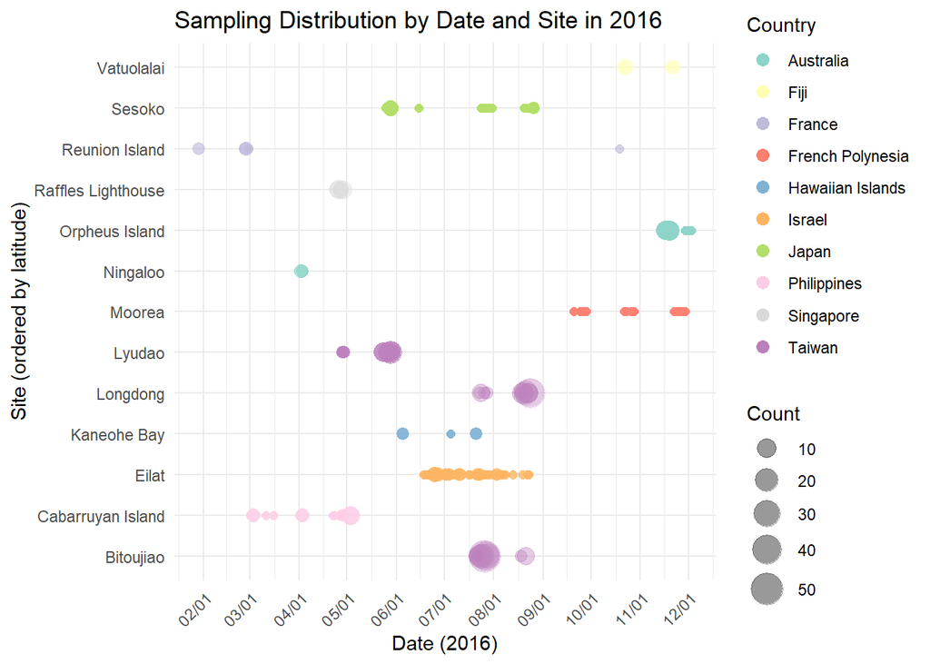

```r
i.want.set3 <- brewer.pal(length(unique(split.data$Country)), "Set3")
#set1_colors：指定點點顏色為Set3！
#unique()：獲取該欄位中所有不重複的值，也就是所有不同的國家。
#length()：計算不重複值的數量，就是總共有幾個國家
#brewer.pal(n, "Set3")：從 RColorBrewer 的 Set3 調色板中提取 n 種顏色

ggplot(split.data2, aes(x =date.x, y = site.y, size = Count, color = Country)) +
  geom_point(alpha = 0.4) +
  scale_size_continuous(name = "Count", range = c(2, 8)) +  # 調整點大小
  scale_color_manual(values = i.want.set3) +
  scale_x_date(date_labels = "%m/%d", date_breaks = "1 month") +
  labs(
    title = "Sampling Distribution by Date and Site in 2016",
    x = "Date (2016)",
    y = "Site (ordered by latitude)",
    color = "Country") +
  theme_minimal() +
  theme(axis.text.x = element_text(angle = 45, hjust = 1),
        scale_fill_discrete(name = "Country")) +
  guides(color = guide_legend(override.aes = list(size = 3, alpha = 1)))
```

```r
split.data2$Country <- factor(split.data2$Country)
```

```r
# Figure 1: World map with all the observed coral spawning sites.
color_palette <- colorFactor(palette = "Set3", domain = levels(split.data2$Country))
leaflet(data = split.data2) %>%
  addTiles() %>%
  addCircleMarkers(
    lng = ~Longitude,
    lat = ~Latitude,
    popup = ~site.y,
    fillOpacity = 1,
    radius = 6,
    weight = 0.5,
    color = "black",
    fillColor = ~color_palette(Country))
```

[interactive chart not shown]

```r
# select the countries needed (Taiwan & Japan)
spawning.jptw <- raw.data %>%
  filter(Country %in% c('Japan', 'Taiwan')) %>%
  filter(Genus %in% c('Galaxea', 'Lobophyllia', 'Coelastrea', 'Dipsastraea', 'Favites', 'Goniastrea', 'Platygyra', 'Porites'))

# delete the unneeded columns
spawning.jptw[ , c('Subsite', 'O_n', 'Depth_m', 'N', 'No_start', 'Quality_start', 'No_end', 'Quality_end', 'Gamete_release', 'Situation', 'Timezone', 'Reference', 'Comments')] <- list(NULL)
spawning.jptw$color <- ifelse(spawning.jptw$Country == "Japan", "#F8766D", "#00BFC4")
```

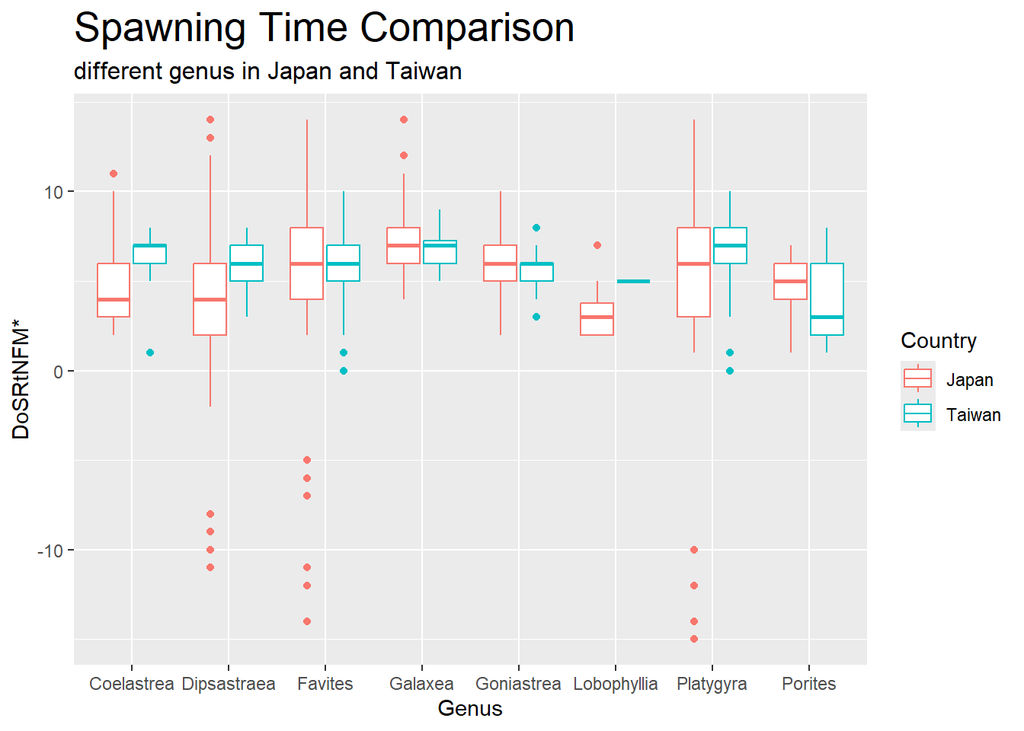

```r
genus.tj.day <- ggplot(data = spawning.jptw, aes(x = Genus, y = DoSRtNFM, color = Country)) +
  geom_boxplot() +
  ggtitle("Spawning Time Comparison", subtitle = "different genus in Japan and Taiwan") +
  ylab("DoSRtNFM*") +
  theme(
    plot.title = element_text(size=20),
    plot.subtitle = element_text(size=12))
genus.tj.day
```

*Date of Spawning Relative to Nearest Full Moon

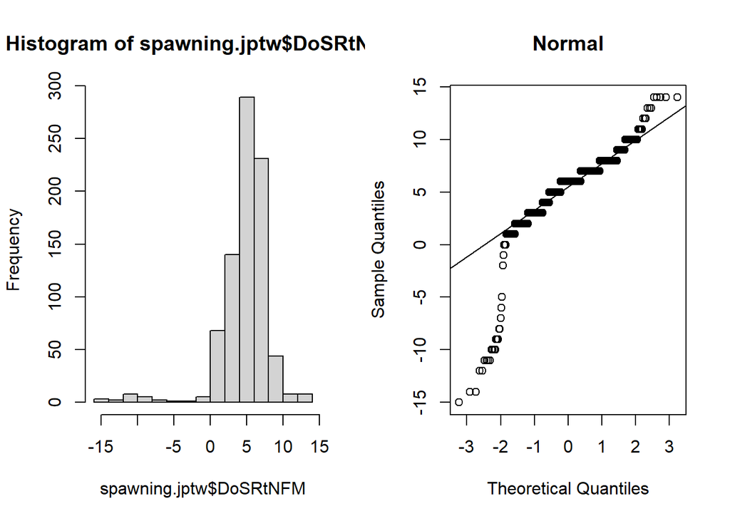

```r
#check normality----
par(mfrow = c(1, 2))
hist(spawning.jptw$DoSRtNFM)
qqnorm(spawning.jptw$DoSRtNFM, main = 'Normal')
qqline(spawning.jptw$DoSRtNFM)
```

```r
#check data number----
J.genus <- spawning.jptw %>%
          filter(Country == "Japan") %>%
          dplyr::select(Genus)
summary(as.factor(J.genus$Genus))
```

```
##  Coelastrea Dipsastraea     Favites     Galaxea  Goniastrea Lobophyllia
##          26          60         109          27          17          14
##   Platygyra     Porites
##          77          21
```

```r
T.genus <- spawning.jptw %>%
  filter(Country == "Taiwan") %>%
  dplyr::select(Genus)
summary(as.factor(T.genus$Genus))
```

```
##  Coelastrea Dipsastraea     Favites     Galaxea  Goniastrea Lobophyllia
##          20          34         249          12          24           1
##   Platygyra     Porites
##          59          65
```

sample size of *Lobophyllia* is too small, so there’s no comparison below

```r
#wilcoxon----
Coelastrea <- spawning.jptw %>%
  filter(Genus %in% "Coelastrea",
         Country %in% c("Taiwan", "Japan"))
wilcox.test(DoSRtNFM ~ Country, data = Coelastrea)
```

```
##
##  Wilcoxon rank sum test with continuity correction
##
## data:  DoSRtNFM by Country
## W = 147, p-value = 0.01138
## alternative hypothesis: true location shift is not equal to 0
```

```r
Dipsastraea <- spawning.jptw %>%
  filter(Genus %in% "Dipsastraea",
         Country %in% c("Taiwan", "Japan"))
wilcox.test(DoSRtNFM ~ Country, data = Dipsastraea)
```

```
##
##  Wilcoxon rank sum test with continuity correction
##
## data:  DoSRtNFM by Country
## W = 548.5, p-value = 0.0001827
## alternative hypothesis: true location shift is not equal to 0
```

```r
Favites <- spawning.jptw %>%
  filter(Genus %in% "Favites",
         Country %in% c("Taiwan", "Japan"))
wilcox.test(DoSRtNFM ~ Country, data = Favites)
```

```
##
##  Wilcoxon rank sum test with continuity correction
##
## data:  DoSRtNFM by Country
## W = 14270, p-value = 0.4295
## alternative hypothesis: true location shift is not equal to 0
```

```r
Galaxea <- spawning.jptw %>%
  filter(Genus %in% "Galaxea",
         Country %in% c("Taiwan", "Japan"))
wilcox.test(DoSRtNFM ~ Country, data = Galaxea)
```

```
##
##  Wilcoxon rank sum test with continuity correction
##
## data:  DoSRtNFM by Country
## W = 184.5, p-value = 0.4918
## alternative hypothesis: true location shift is not equal to 0
```

```r
Goniastrea <- spawning.jptw %>%
  filter(Genus %in% "Goniastrea",
         Country %in% c("Taiwan", "Japan"))
wilcox.test(DoSRtNFM ~ Country, data = Goniastrea)
```

```
##
##  Wilcoxon rank sum test with continuity correction
##
## data:  DoSRtNFM by Country
## W = 259.5, p-value = 0.1361
## alternative hypothesis: true location shift is not equal to 0
```

```r
Platygyra <- spawning.jptw %>%
  filter(Genus %in% "Platygyra",
         Country %in% c("Taiwan", "Japan"))
wilcox.test(DoSRtNFM ~ Country, data = Platygyra)
```

```
##
##  Wilcoxon rank sum test with continuity correction
##
## data:  DoSRtNFM by Country
## W = 1934, p-value = 0.1354
## alternative hypothesis: true location shift is not equal to 0
```

```r
Porites <- spawning.jptw %>%
  filter(Genus %in% "Porites",
         Country %in% c("Taiwan", "Japan"))
wilcox.test(DoSRtNFM ~ Country, data = Porites)
```

```
##
##  Wilcoxon rank sum test with continuity correction
##
## data:  DoSRtNFM by Country
## W = 852, p-value = 0.08582
## alternative hypothesis: true location shift is not equal to 0
```

```r
split <- raw.data %>%
  separate(Date, into = c("day", "month", "year"), sep = "/")
summary(as.factor(split$year))
```

```
## 1978 1979 1980 1981 1982 1983 1984 1985 1986 1987 1988 1989 1990 1991 1992 1993
##    9   17    6   69   96  241  147   18   23  141   25  229  165  166  134  214
## 1994 1995 1996 1997 1998 1999 2000 2001 2002 2003 2004 2005 2006 2007 2008 2009
##  116   88   37  113   31   79   51   33  130  110   75  102  164  142   93  111
## 2010 2011 2012 2013 2014 2015 2016 2017 2018 2019
##  115  170  346  165  379  365  589  328  369  177
```

```r
max(summary(as.factor(split$year)))
```

```
## [1] 589
```

```r
split.data <- raw.data %>%
  separate(Date, into = c("day", "month", "year"), sep = "/") %>% #先把年月日拆開才能篩選2016
  filter(year == 2016) %>%
  mutate(
    date.x = as.Date(paste(year, month, day, sep = "-"), "%Y-%m-%d"),
    site.y = fct_reorder(Site, Latitude, .desc = FALSE)) %>% # 根據緯度重新排列地點
  group_by(date.x, site.y, Country) %>%  # 處理點點大小：把同天site同country的數據分在同一坨
  summarise(Count = n())# n()功能可以算算同一坨有多少個。接著命名為 Count
split.data2 <- split.data %>%
  left_join(
    raw.data %>%
      dplyr::select(Site, Latitude, Longitude) %>%
      distinct(), by = c("site.y" = "Site"))
```

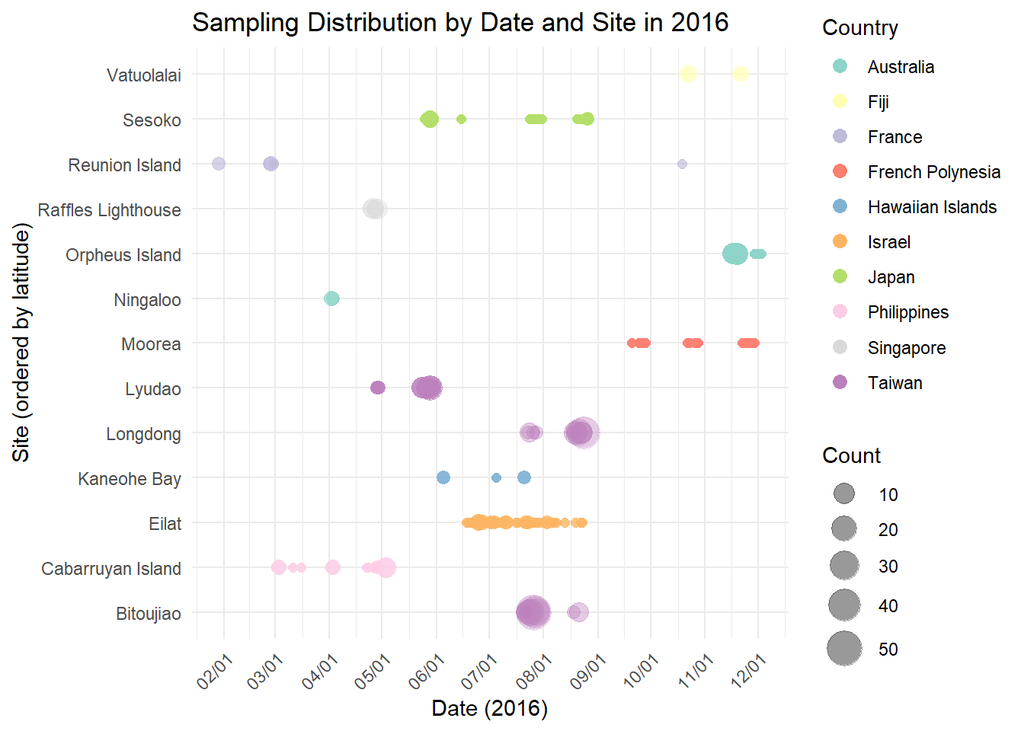

```r
i.want.set3 <- brewer.pal(length(unique(split.data$Country)), "Set3")
#set1_colors：指定點點顏色為Set3！
#unique()：獲取該欄位中所有不重複的值，也就是所有不同的國家。
#length()：計算不重複值的數量，就是總共有幾個國家
#brewer.pal(n, "Set3")：從 RColorBrewer 的 Set3 調色板中提取 n 種顏色

ggplot(split.data2, aes(x =date.x, y = site.y, size = Count, color = Country)) +
  geom_point(alpha = 0.4) +
  scale_size_continuous(name = "Count", range = c(2, 8)) +  # 調整點大小
  scale_color_manual(values = i.want.set3) +
  scale_x_date(date_labels = "%m/%d", date_breaks = "1 month") +
  labs(
    title = "Sampling Distribution by Date and Site in 2016",
    x = "Date (2016)",
    y = "Site (ordered by latitude)",
    color = "Country") +
  theme_minimal() +
  theme(axis.text.x = element_text(angle = 45, hjust = 1),
        scale_fill_discrete(name = "Country")) +
  guides(color = guide_legend(override.aes = list(size = 3, alpha = 1)))
```

```r
split.data2$Country <- factor(split.data2$Country)
```

```r
# Figure 1: World map with all the observed coral spawning sites.
color_palette <- colorFactor(palette = "Set3", domain = levels(split.data2$Country))
leaflet(data = split.data2) %>%
  addTiles() %>%
  addCircleMarkers(
    lng = ~Longitude,
    lat = ~Latitude,
    popup = ~site.y,
    fillOpacity = 1,
    radius = 6,
    weight = 0.5,
    color = "black",
    fillColor = ~color_palette(Country))
```

[interactive chart not shown]